# Project Proposal

Erik Istre

April 18, 2016

The following two plots provide a basic analysis of what information is available in reviews on a service like Yelp and what challenges this information will present for the proposed project.

The first provides a basic analysis of keywords after pre-processing on the corpus of review text. All punctuation was removed, words like “I” and “the” were taken out, all words were made lower case, and stems like “ing” were removed. This graph plots various test keywords that would be of interest for the concierge project, like “romant” for “romantic”, “date” and “prett” for “pretty”, against the log of their counts. Some words presented with significantly higher counts than the others, and thus the logarithm was necessary to show information about all of the test keywords.

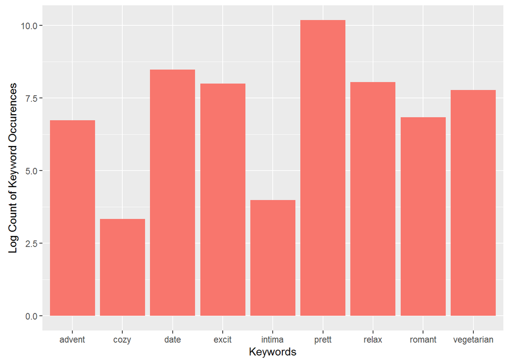

This plot shows that for the selected keywords there is likely to be enough information to categorize the “nature” of the activity, i.e. whether it is considered romantic or not. Such categories would be the first step in determining what might go well together in recommendations.

The second digs a little bit deeper into two keywords, “date” and “romant” to determine what businesses have reviews where these words occur. These keywords occurred often enough that it was fruitful to look further. As it turns out, the categories extend a lot further than we might initially expect. For instance, under the “date” keyword we find a business with the “Automotive”. This is likely due to a different meaning of the word “date” and it highlights the difficulty in finding the businesses which correspond precisely with the meaning of the keyword we have in mind. This problem could be remedied by more rigorous analysis beyond basic keyword analysis.

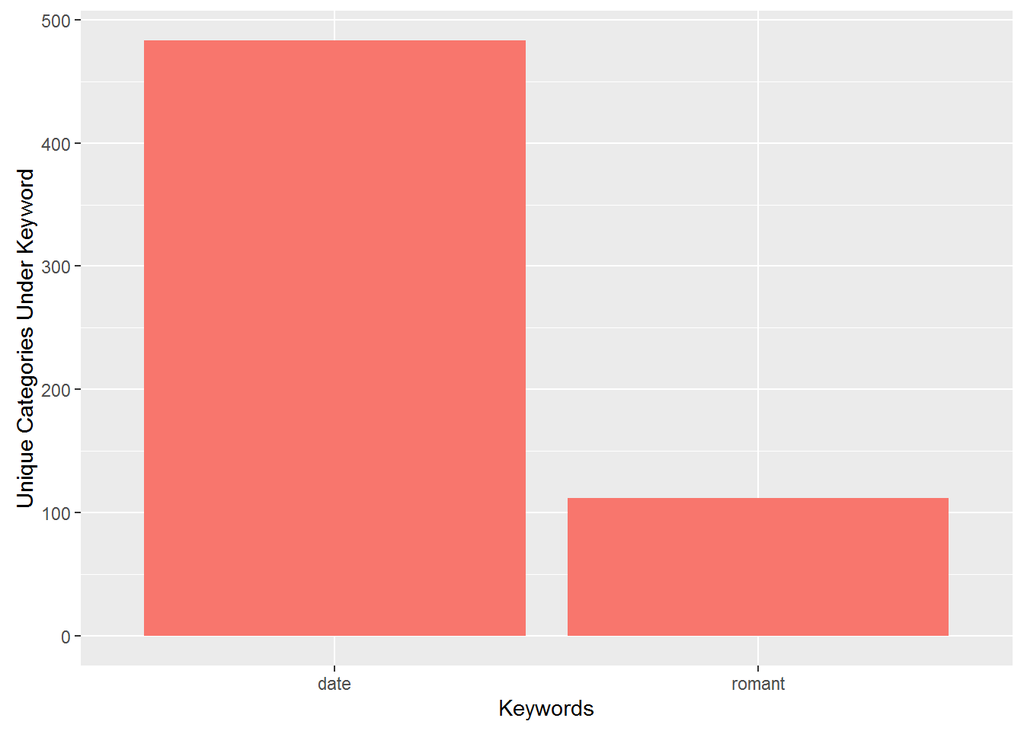